# Lab 03: Heteroskedasticity

Andrew Dickinson

In this lab, we will delve into the concept of heteroskedasticity, an important phenomenon in regression analysis. Heteroskedasticity refers to the circumstance where the variability of a variable is unequal across the range of values of another variable to which it is related. This is often a violation of the Gauss-Markov assumptions underlying the classical linear regression model.

We will explore how to identify and test for heteroskedasticity using R, particularly focusing on the Goldfeld-Quandt test and White’s test. Additionally, we will look into the use of `ggplot2` for visualizing residuals, which can be a great way to check for heteroskedasticity.

## Prerequisites

Load the necessary libraries and set the theme for plots.

```r
library(pacman)
p_load(tidyverse, fixest)
theme_set(hrbrthemes::theme_ipsum())
```

## Generating Simulated Data

First, let’s create some simulated data to work with.

```r
set.seed(12345)
n=1000
data = tibble(
  x=rnorm(n, 2, 1),
  group=c(rep(0,n/2), rep(1,n/2)),
  error = rnorm(n, 0, 1),
  y_homo =  error,
  y_hetero1= error*x,
  y_hetero2= error*abs(x-2),
  y_hetero3= error*(group+1)*3,
)
# Optional: Save the data to a CSV file
#write_csv(data, file="Data_Heteroskedasticity.csv")
```

## Visualizing data

### `ggplot2`

`ggplot2` is built upon the principles outlined in “The Grammar of Graphics” by Leland Wilkinson. This grammar provides a powerful structure for systematically building up graphics step by step. The core philosophy behind `ggplot2` is to visualize data as a combination of layered elements. Each layer can represent data points, statistical summaries, or even annotations. By stacking layers on top of each other, users can create complex visualizations in a structured and incremental manner.

#### Layers in `ggplot2`

The layering principle is crucial to understanding how `ggplot2` operates. Each layer in a `ggplot2` graphic is composed of several distinct components:

1. **Data**: The dataset to be visualized.
2. **Aesthetic Mappings**: Descriptions of how variables in the data are mapped to aesthetic properties of the layer such as position, size, color, shape, etc.
3. **Geometric Object (Geom)**: The geometric representation of the data like points (`geom_point()`), lines (`geom_line()`), or bars (`geom_bar()`).
4. **Statistical Transformation (Stat)**: The statistical summary, if any, that needs to be performed on the data like binning, smoothing, etc.
5. **Position Adjustment**: Adjustments to position of geoms, like stacking bars on top of each other.

You initiate a plot using the `ggplot()` function, specifying the data and the aesthetic mappings. This creates a coordinate system that you can add layers to.

```r
# Initiate a plot
p = ggplot(data, aes(x = x, y = y_homo))
```

Next, add layers to this plot using `+` operator. For example, to create a scatter plot, add a point geom:

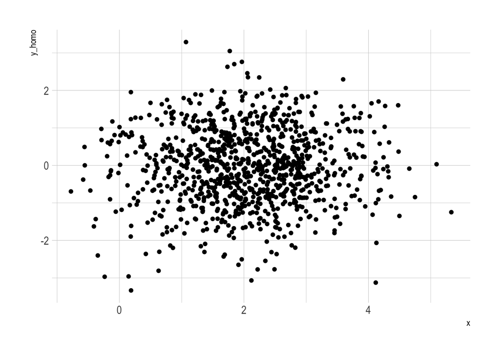

```r
# Add a layer of points
p + geom_point()
```

You can continue adding layers, like a smooth line or text annotations, each with its own aesthetics, geoms, and stats.

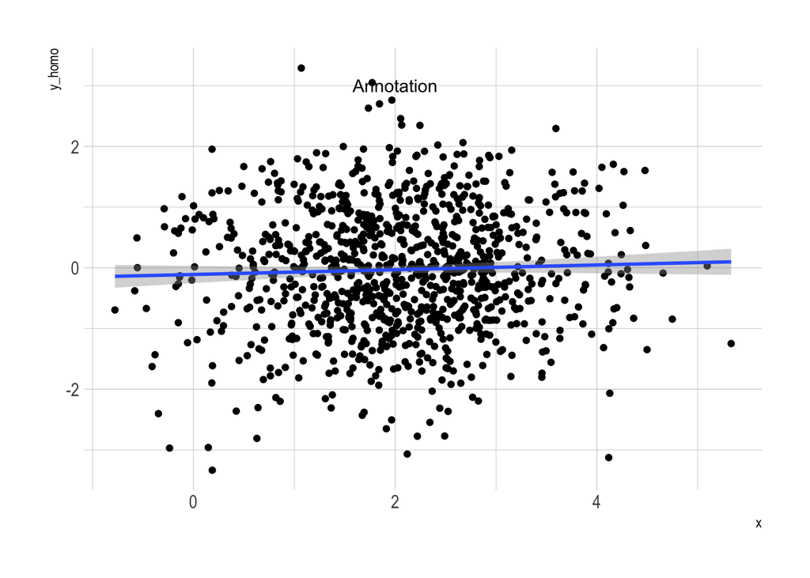

```r
# Add a layer of smooth line and text annotation
p + geom_point() +
  geom_smooth(method = "lm") +
  annotate("text", x = 2, y = 3, label = "Annotation")
```

Each layer is independent and can operate on different data, have its own aesthetic mappings, and even have its own coordinate system. This layering system allows for a high degree of customization and complexity while maintaining a structured approach to plotting. This layered approach also makes it easy to modify or update plots, as you can adjust individual layers without affecting the rest of the plot.

The `ggplot2` system’s consistency and structure make it a powerful tool for creating a wide range of static graphics efficiently and intuitively. Through the exploration of layers and aesthetic mappings, users can create complex visualizations that effectively communicate data-driven insights.

#### Resources

- [ggplot2 page](https://ggplot2.tidyverse.org/)
- [ggplot2 book](https://ggplot2-book.org/)
- [R graph gallery](https://r-graph-gallery.com/ggplot2-package.html)

### Visualizing the generated data

Visualization is a crucial step in understanding the data and the relationships among variables. Let’s visualize the relationships between $x$ and different simulated dependent variables using `ggplot2`.

**y_homo**

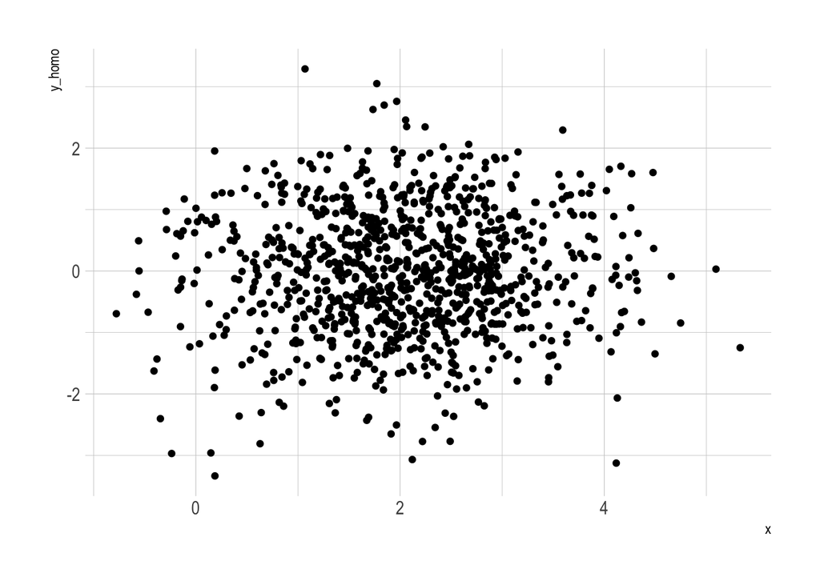

```r
ggplot(data=data, aes(x=x, y=y_homo)) +
  geom_point()
```

**y_hetero1**

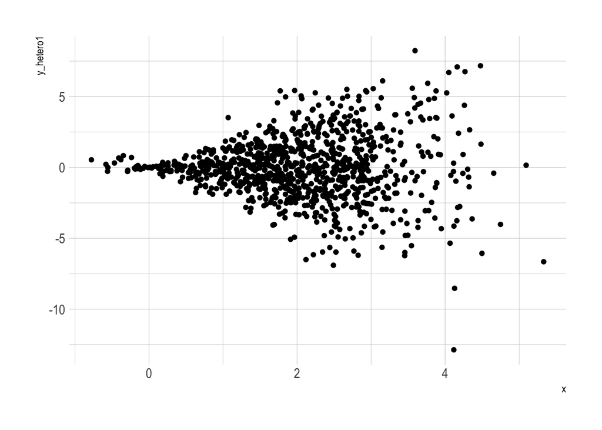

```r
ggplot(data=data, aes(x=x, y=y_hetero1)) +
  geom_point()
```

**y_hetero2**

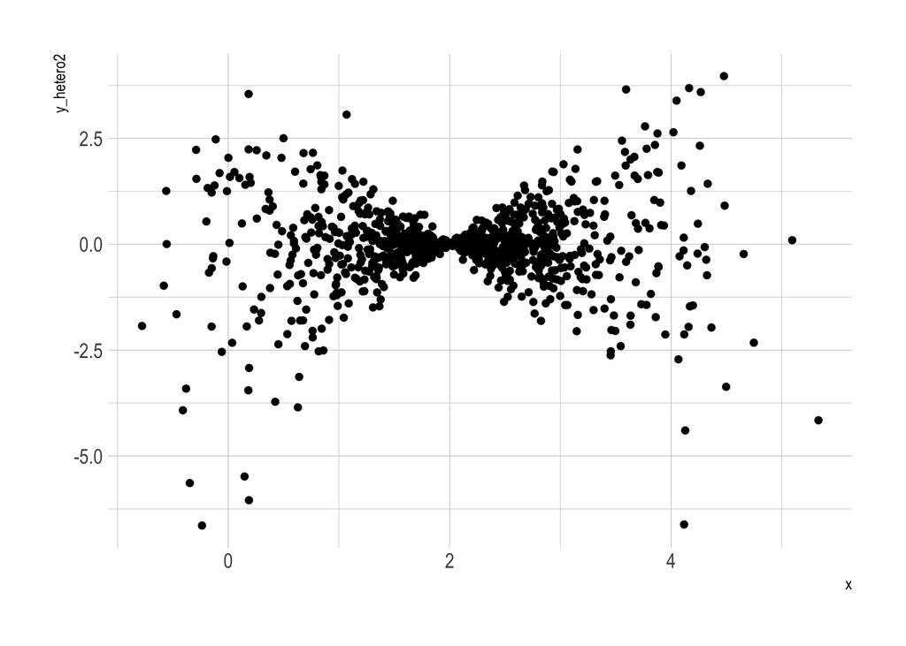

```r
ggplot(data=data, aes(x=x, y=y_hetero2)) +
  geom_point()
```

**y_hetero3**

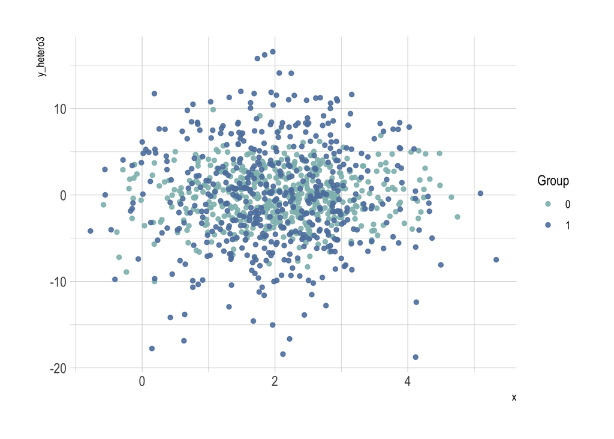

```r
ggplot(data=data, aes(x=x, y=y_hetero3, color=factor(group))) +
  geom_point(alpha=0.9) +
  scale_color_manual(values = c(
    nord::nord_palettes$frost[1],
    nord::nord_palettes$frost[4])
    ) +
  labs(
    color = "Group"
  )
```

```r
  theme(
    legend.position = "bottom"
  )
```

```
List of 1
 $ legend.position: chr "bottom"
 - attr(*, "class")= chr [1:2] "theme" "gg"
 - attr(*, "complete")= logi FALSE
 - attr(*, "validate")= logi TRUE
```

# Goldfeld-Quandt Test

The Goldfeld-Quandt (GQ) test is a classical statistical procedure used to check for heteroskedasticity in a regression model. Heteroskedasticity, a violation of one of the Gauss-Markov assumptions, occurs when the variance of the error terms is not constant across observations. This test is particularly useful when the variances are believed to change at a particular point of a covariate or across groups. The GQ test splits the data into different segments, performs separate regression analyses on these segments, and tests whether the variances of the residuals from these regressions are significantly different.

## Goldfeld-Quandt Test in R

1. **Sort the Data**:
   - Arrange the data in ascending order based on the independent variable suspected to exhibit heteroskedasticity.

```r
data = data %>%
  arrange(x)
```

2. **Split the Data**:
   - Divide the data into two or more segments. A common approach is to split it into thirds and discard the middle third.

```r
first_third = nrow(data)/3
third_third = floor((nrow(data)/3) * 2) + 2
data_1 = data[1:first_third, ]
data_2 = data[third_third:n, ]
```

3. **Run Separate Regressions**:
   - Perform regression analyses on these segments separately.

```r
fit1 = lm(y_hetero2 ~ x, data_1 )  %>% summary()
fit2 = lm(y_hetero2 ~ x, data_2 )  %>% summary()
```

4. **Compute Residual Sum of Squares (RSS)**:
   - Calculate the sum of squared residuals for each regression.

```r
rss1 = sum(resid(fit1)^2)
rss2 = sum(resid(fit2)^2)
```

5. **Conduct Hypothesis Testing**:
   - Compare the variances of the residuals from these regressions using an F-test.
   - The null hypothesis ($H_0$) is that the variances are equal (Homoskedasticity), against the alternative hypothesis ($H_1$) that they are not equal (Heteroskedasticity).

```r
tstat = rss2/rss1
pf(q = tstat, df1 = 333-1, df2 = 333-1, lower.tail = F)
```

[output not shown]

The GQ test is a straightforward and intuitive method to test for heteroskedasticity, especially when there is a prior belief that the variance of errors may change at a particular point of a covariate.

# White’s Test

White’s Test is a statistical procedure that helps detect heteroskedasticity in a regression model. Unlike the Goldfeld-Quandt Test, White’s Test does not require the data to be sorted, nor does it require the assumption that variances change at a particular point of a covariate. Instead, it’s a general test for heteroskedasticity without specifying the form of heteroskedasticity.

## White’s Test in R

1. **Run the Initial Regression**:
   - Perform a regression analysis using the suspected model.

```r
fit = lm(y_hetero2 ~ x, data)
```

2. **Compute Squared Residuals**:
   - Obtain the residuals from the regression and square them.

```r
data = data %>% mutate(resid = resid(fit)^2)
```

3. **Regress Squared Residuals on Original Independent Variable(s), Their Squares and Cross Products**:
   - Perform a regression of the squared residuals on the original independent variable(s), their squares, and the cross products of the independent variables.

```r
fit = lm(resid ~ x + I(x^2), data) %>% summary()
```

4. **Conduct Hypothesis Testing**:
   - The test statistic is computed as $N \cdot R^2$ from the regression in step 3, where $N$ is the sample size and $R^2$ is the coefficient of determination from the regression.
   - Under the null hypothesis of homoskedasticity, the test statistic follows a chi-square distribution with degrees of freedom equal to the number of regressors (excluding the constant term) in the regression in step 3.

```r
teststat = fit$r.squared * n
pchisq(q = teststat, df = 2, lower.tail = F)
```

[output not shown]

White’s Test provides a non-specific approach to detect heteroskedasticity, making it a flexible option when the form of heteroskedasticity is unknown. It’s a widely used test due to its generality and simplicity in implementation.